# Predicting Weight Lifting Techniques Using Machine Learning

sdbj2063

July 17, 2015

## Original Research into Qualitative Activity Recognition

Five researchers across the globe asked a critical machine learning question: What technology resources and data analytic methods can we use effectively to identify the quality of physical motions? [The Human Activity Recognition Weight Lifting Exercises Dataset project](http://groupware.les.inf.puc-rio.br/har) used four motion sensors on the belt, forearm, arm and dumbell of six male participants and recorded their performance of barbell lifts in five prescribed ways, one correctly and four incorrectly.

In their research paper, [Qualitative Activity Recognition of Weight Lifting Exercises](http://groupware.les.inf.puc-rio.br/public/papers/2013.Velloso.QAR-WLE.pdf), they spelled out the five classes of Unilateral Dumbbell Biceps Curl exercises that the subjects performed:

1. Exactly according to the specification (correct method)
2. Throwing the elbows to the front
3. Lifting the dumbbell only halfway
4. Lowering the dumbbell only halfway
5. Throwing the hips to the front

The researchers “…calculated features on the Euler angles (roll, pitch and yaw), as well as the raw accelerometer, gyroscope and magnetometer readings.” Using the three angles on each of the four sensors, they calculated eight features, resulting in a total of 96 feature sets. The primary features were “…mean, variance, standard deviation, max, min, amplitutde, kurtosis and skewness.” The sensors recorded readings in seconds of time.

Using a best fit model, the researchers selected 17 features for their model and used the Random Forest algorithm with the “Bagging” method and 10-fold cross-validation.

## Practical Machine Learning Project Description

The goal of this project was two-fold:  
1. Build a model to predict in what class a subject performed an exercise.  
2. Predict the class for each of the 20 test records.

The data comes from the project described above  
Training set https://d396qusza40orc.cloudfront.net/predmachlearn/pml-training.csv and  
Testing set https://d396qusza40orc.cloudfront.net/predmachlearn/pml-testing.csv

## Load Libraries and Training Data

The process loaded the libraries using the most current versions of the packages, including `caret` and `randomForest`, and imported the training data set into R 3.2.1.

```r
## Load training data
pmltraining <- read.csv("pml-training.csv", na.strings = c("NA", "", "#DIV/0!"))
myrows <- nrow(pmltraining)
myvars <- ncol(pmltraining)
```

Loading the training data using `read.csv()` from the working directory resulted in a large dataset with 19622 rows and 160 variables. When importing the data, the process Changed values of “NA,” empty strings and “#DIV/0!” to NA values.

## Partitioning and Cleaning the Data

The best process for developing the model was to partition the data into a training group and a testing group. Step 1 was to divide the data into two groups. Due to concerns about length of processing time on available machines (a minimum of 1.3 hours without the report processing), the script split the data set into two equal sets.

```r
## Clean the Data
### Set seed
### Create partitions for training and testing
set.seed(665)
inTrain <- createDataPartition(y = pmltraining$classe, p = 0.50, list = FALSE)
training <- pmltraining[inTrain, ]
testing <- pmltraining[-inTrain, ]
dim(training); dim(testing)
```

```
## [1] 9812  160
```

```
## [1] 9810  160
```

Two obvious issues to consider for data quality were variables with predominatly NA values and variables that were not essential to the analysis. In the first instance, variables populated only when the field `NEW_WINDOW = YES` were good candidates for deletion. In the second instance, candidate variables included user information and time.

Searching `new_window` for `YES` values was an easy mechanism to test the population of the first. A visual inspection of the data resolved the second issue.

```r
## Remove columns
## recalculate number of columns
training.nocols <- training
training.nocols[df.names] <- list(NULL)
ncol.training <- ncol(training.nocols)
```

```r
##  Create column list
##  Remove columns from training set
cols.char <- c("X", "user_name", "raw_timestamp_part_1", "raw_timestamp_part_2", "cvtd_timestamp", "new_window", "num_window")
training.nocols[cols.char] <- list(NULL)
```

After removing 7 columns that were character data types, the final data set `training.nocols` contained 53 variables, a manageable number.

## Exploring the Data

Exploring the data included identifying any other variables that were of no consequence and identifying possible variable candidates for the model formula. To accomplish these two goals required calculating Near Zero (NZ) covariants and perfoming a manual Principal Components Analysis (PCA).

```r
## Perform NZ analysis
## Display the number of TRUE and FALSE for the zeroVar and nzv variables.
training.nzv <- nearZeroVar(training.nocols, saveMetrics = TRUE)
count(training.nzv$zeroVar); count(training.nzv$nzv)
```

```
##       x freq
## 1 FALSE   53
```

```
##       x freq
## 1 FALSE   53
```

Data cleaning removed any variables that might have been TRUE for `zeroVar` or `nzv`. That meant the remaining variables were reasonable formula candidates. PCA identified important variables for consideration when building the formula.

```r
absolute.M <- abs(cor(training.nocols[ , -53]))
diag(absolute.M) <- 0
absolute.M.80 <- which(absolute.M > 0.8, arr.ind = T)
absolute.M.80.un <- unique(absolute.M.80[,2])
absolute.M.80.un.len <- length(unique(absolute.M.80[,2]))
```

At the 80 percent threshold the system identified 18 unique variables. A higher threshold would have narrowed the list further. The most likely candidates included the following:

```
##  [1] "roll_belt"        "pitch_belt"       "yaw_belt"
##  [4] "total_accel_belt" "accel_belt_x"     "accel_belt_y"
##  [7] "accel_belt_z"     "magnet_belt_x"    "gyros_arm_x"
## [10] "gyros_arm_y"      "accel_arm_x"      "magnet_arm_x"
## [13] "magnet_arm_y"     "magnet_arm_z"     "pitch_dumbbell"
## [16] "yaw_dumbbell"     "accel_dumbbell_x" "accel_dumbbell_z"
```

THeoretically, with time permitting, this list plus the pair ranking from the correlation table would have provided a good first list for a manual formula development. Time limitations forced using the `train` command with predefinded methods to develop the model.

## Exploring the Random Forest Model

Due to memory processing power constraints and time limitations, the program only examined the Random Forest method as the possible machine learning algorithm to accurately predict weight lifting activity. This seemed like the most likely candidate considering the fact that the researchers on the published paper used that algorithm.

### Define the Model with Cross Validation

The first step was to define the train control parameters and use the `train` function to execute the random forest method against the training data set. The reampling method was cross validation with 10 resampling iterations and one repeat. This process took the most time and required multiple attempts on two different machines and virtual memory adjustments before the code successfully executed without error and within a reasonable timeframe.

```r
## Define the train control parameters
## Run train() to define the model
tc.params <- trainControl(method = "cv", number = 10, repeats = 1)
modFit.rf <- train(classe ~ ., data = training.nocols, method = "rf", trControl = tc.params)
modFit.rf.mtry <- modFit.rf$bestTune
modFit.rf.mtry.num <- as.numeric(modFit.rf$bestTune)
modFit.rf.metric <- modFit.rf$metric
modFit.rf
```

```
## Random Forest
##
## 9812 samples
##   52 predictor
##    5 classes: 'A', 'B', 'C', 'D', 'E'
##
## No pre-processing
## Resampling: Cross-Validated (10 fold)
## Summary of sample sizes: 8830, 8831, 8831, 8830, 8831, 8831, ...
## Resampling results across tuning parameters:
##
##   mtry  Accuracy   Kappa      Accuracy SD  Kappa SD
##    2    0.9885858  0.9855600  0.002911258  0.003684203
##   27    0.9876694  0.9844000  0.003997859  0.005058911
##   52    0.9782919  0.9725338  0.004160521  0.005264696
##
## Accuracy was used to select the optimal model using  the largest value.
## The final value used for the model was mtry = 2.
```

The evaluation metric was Accuracy, and the best model for tuning was 2. The 10 resampling results, listed below, showed a high and low range of 0.9918534 and 0.9826884 for `Accuracy`.

```
##     Accuracy     Kappa Resample
## 1  0.9877676 0.9845209   Fold02
## 2  0.9826884 0.9780952   Fold01
## 3  0.9887870 0.9858181   Fold03
## 4  0.9867482 0.9832384   Fold06
## 5  0.9918451 0.9896833   Fold05
## 6  0.9918534 0.9896945   Fold04
## 7  0.9867617 0.9832507   Fold07
## 8  0.9897855 0.9870784   Fold10
## 9  0.9877676 0.9845261   Fold09
## 10 0.9918534 0.9896948   Fold08
```

The `finalModel` attribute of the model showed a favorable `Confusion Matrix` and `OOB` estimate of the error rate.

```r
modFit.rf$finalModel
```

```
##
## Call:
##  randomForest(x = x, y = y, mtry = param$mtry)
##                Type of random forest: classification
##                      Number of trees: 500
## No. of variables tried at each split: 2
##
##         OOB estimate of  error rate: 1.09%
## Confusion matrix:
##      A    B    C    D    E class.error
## A 2784    6    0    0    0 0.002150538
## B   16 1875    8    0    0 0.012638231
## C    1   22 1684    4    0 0.015780245
## D    0    0   37 1569    2 0.024253731
## E    0    0    6    5 1793 0.006097561
```

The data set contained 52 variables, which the random forest model dutifully evaluated. The top 20 ranked by `Importance` demonstrated an interesting pattern favoring 15-17 variables.

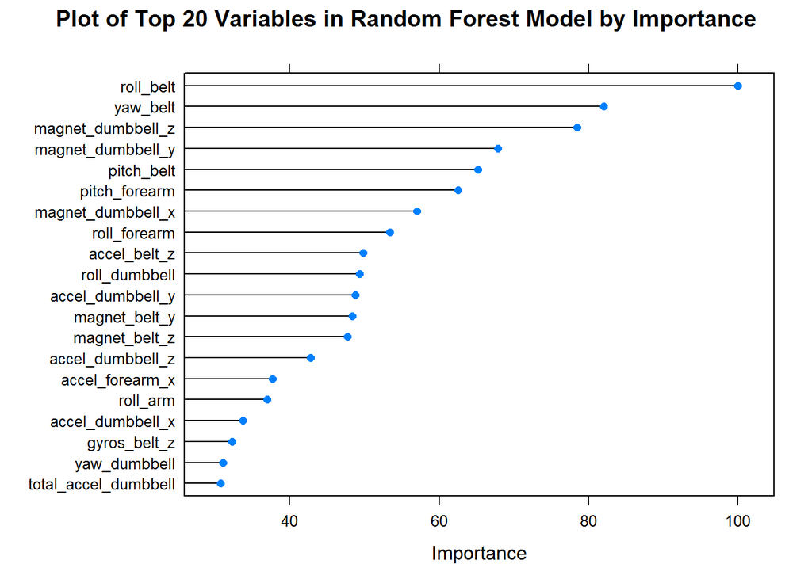

Comparing the predictors to accuracy within the model indicated a clear preference and cutoff for benefits to the model.

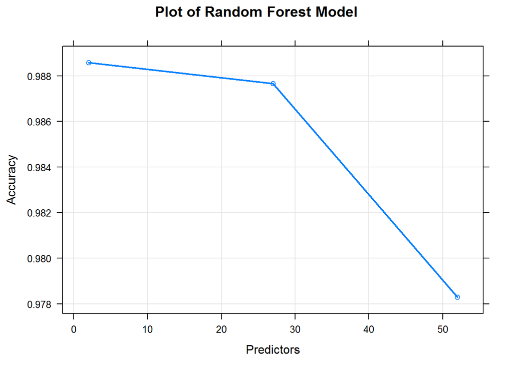

### Evaluating the Model

#### Runing Time

The time to run the model on the data set on the available equipment was a disadvantage as the time logs recorded. The elapsed time for the entire `train()` call was 1.3050667 hours. That’s not surprising since the preferred model tree had 2079 splits.

#### Confusion Matrix

The confusion matrix comparing the predictions on the training data to the actual `classe` value was very favorable, which was to be expected since the system developed the model on that data set. The first table, which compared the “Reference” values of correct predictions for `classe` to the “Prediction” values demonstrated the model performed well.

```r
training.predictions <- predict(modFit.rf, newdata=training.nocols)
training.confMatrix <- confusionMatrix(training.predictions, training.nocols$classe)
training.confMatrix
```

```
## Confusion Matrix and Statistics
##
##           Reference
## Prediction    A    B    C    D    E
##          A 2790    0    0    0    0
##          B    0 1899    0    0    0
##          C    0    0 1711    0    0
##          D    0    0    0 1608    0
##          E    0    0    0    0 1804
##
## Overall Statistics
##
##                Accuracy : 1
##                  95% CI : (0.9996, 1)
##     No Information Rate : 0.2843
##     P-Value [Acc > NIR] : < 2.2e-16
##
##                   Kappa : 1
##  Mcnemar's Test P-Value : NA
##
## Statistics by Class:
##
##                      Class: A Class: B Class: C Class: D Class: E
## Sensitivity            1.0000   1.0000   1.0000   1.0000   1.0000
## Specificity            1.0000   1.0000   1.0000   1.0000   1.0000
## Pos Pred Value         1.0000   1.0000   1.0000   1.0000   1.0000
## Neg Pred Value         1.0000   1.0000   1.0000   1.0000   1.0000
## Prevalence             0.2843   0.1935   0.1744   0.1639   0.1839
## Detection Rate         0.2843   0.1935   0.1744   0.1639   0.1839
## Detection Prevalence   0.2843   0.1935   0.1744   0.1639   0.1839
## Balanced Accuracy      1.0000   1.0000   1.0000   1.0000   1.0000
```

### Predictions Plot

The jitter box plot demonstrated a clear and significant pattern for each `classe`.

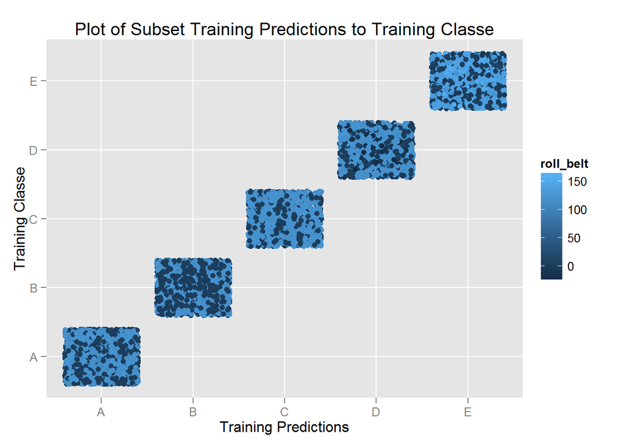

```r
qplot(training.predictions, classe, colour = roll_belt, geom=c("boxplot", "jitter"), data = training.nocols, main = "Plot of Subset Training Predictions to Training Classe", xlab = "Training Predictions", ylab = "Training Classe")
```

#### In Sample Error

The in-sample error rate was 1 minus the accuracy of the model. The error rate for the model on the training data set was very low. Usually the in-sample error rate was optimistic, so the out-of-sample error rate should be a bit higher. With cross validation already in the model, the may not be the case.

```r
modFit.rf.results <- modFit.rf$results
modFit.rf.results.accuracy <- modFit.rf$results$Accuracy
training.ise <- (as.numeric(1 - max(modFit.rf.results.accuracy)))*100
training.ise
```

```
## [1] 1.141423
```

All in all, the model results promised effective results for applying the model to the testing data set and the 20-row prediction data set.

## Fitting the Model to the Subsetted Test Data

The next step in the process was to apply the random forest model to the testing data subsetted from the pml-training.csv file. The process involved applying the same data transformation steps to the data and using the model to predict the results.

```r
set.seed(665)
testing.nocols <- testing
testing.nocols[df.names] <- list(NULL)      ## Remove new_window = yes columns
testing.nocols[cols.char] <- list(NULL)     ## Remove character columns
## Apply the training model to the testing subset
testing.predictions <- predict(modFit.rf, testing.nocols)
dim(testing.nocols)
```

```
## [1] 9810   53
```

### Evaluating the Model’s Performance

As with the training data, the evaluation methods included a confusion matrix, a table of the testing predictions and a plot of the predictions.

#### Confusion Matrix

The confusion matrix demonstrated that the model correctly identified the vast majority of the `classe` values. The confusion matrix included a table of predictions and `classe` values, Prediction by Reference. The Accuracy and Statistics by Class table demonstrated values very close to the model results on the training data.

```r
testing.confMatrix <- confusionMatrix(testing.predictions,testing.nocols$classe)
testing.confMatrix
```

```
## Confusion Matrix and Statistics
##
##           Reference
## Prediction    A    B    C    D    E
##          A 2785   17    0    0    0
##          B    3 1870   21    0    0
##          C    2   11 1687   23    9
##          D    0    0    3 1584    2
##          E    0    0    0    1 1792
##
## Overall Statistics
##
##                Accuracy : 0.9906
##                  95% CI : (0.9885, 0.9924)
##     No Information Rate : 0.2844
##     P-Value [Acc > NIR] : < 2.2e-16
##
##                   Kappa : 0.9881
##  Mcnemar's Test P-Value : NA
##
## Statistics by Class:
##
##                      Class: A Class: B Class: C Class: D Class: E
## Sensitivity            0.9982   0.9852   0.9860   0.9851   0.9939
## Specificity            0.9976   0.9970   0.9944   0.9994   0.9999
## Pos Pred Value         0.9939   0.9873   0.9740   0.9969   0.9994
## Neg Pred Value         0.9993   0.9965   0.9970   0.9971   0.9986
## Prevalence             0.2844   0.1935   0.1744   0.1639   0.1838
## Detection Rate         0.2839   0.1906   0.1720   0.1615   0.1827
## Detection Prevalence   0.2856   0.1931   0.1766   0.1620   0.1828
## Balanced Accuracy      0.9979   0.9911   0.9902   0.9922   0.9969
```

#### Predictions Plot

The jitter box plot demonstrated a clear and significant pattern for each `classe` that matched the training data plot with a few outliers.

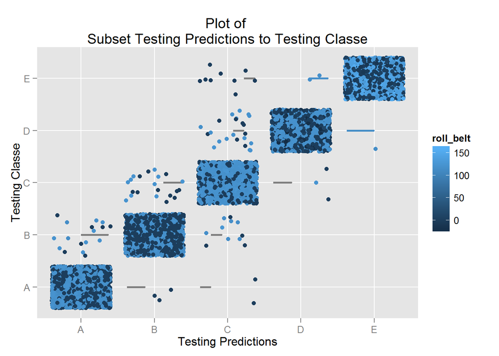

### Out-of-Sample Error

The out-of-sample error rate refers to the error obtained when applying the model to data other than the data used to develop the model. As with the in-sample error rate, the out-of-sample error rate is 1 minus the `Accuracy` of the model’s performance. The code below manually calculated accuracy and obtained the accuracy from the confusion matrix.

```r
testing.nocols.accuracy.est <- sum(testing.predictions == testing.nocols$classe)/length(testing.predictions)
testing.nocols.accuracy.est
```

```
## [1] 0.9906218
```

```r
testing.confMatrix$overall[1]
```

```
##  Accuracy
## 0.9906218
```

```r
testing.ose <- (as.numeric(1 - testing.confMatrix$overall[1]))*100
testing.ose
```

```
## [1] 0.9378186
```

The final step in the process required applying the model to the segregated 20-row data set to obtain the predictions.

## Applying the Model to the 20-row Prediciton Data

### Import the Test Data and Remove Columns

As with the previous attempts, the process imported the data, removed data columns and applied the model to the remaining data.

```r
pmltesting <- read.csv("pml-testing.csv", na.strings = c("NA", "", "#DIV/0!"))
set.seed(665)
pmltesting.nocols <- pmltesting
pmltesting.nocols[df.names] <- list(NULL)
pmltesting.nocols[cols.char] <- list(NULL)
dim(pmltesting.nocols)
```

```
## [1] 20 53
```

Unlike the model development process, applying the model to this data set was quick. The data set did not have any reference values with which to compare the prediction results, so the grade for the class submission was the TRUE or FALSE test evaluation.

```r
pmltesting.predictions <- predict(modFit.rf, pmltesting.nocols)
pmltesting.predictions
```

```
##  [1] B A B A A E D B A A B C B A E E A B B B
## Levels: A B C D E
```

## Conclusions

### 1. In Sample and Out of Sample Error Rates

In theory, the in-sample error rate should have been more optimistic, or smaller, than the out-sample error rate.

```r
training.ise; testing.ose
```

```
## [1] 1.141423
```

```
## [1] 0.9378186
```

One explanation for the reverse in this logic may be that the algorithm applied the cv method and performed 10 interations of resampling. Lou Brieman of University of California Berkeley found empirical evidence that random forest was highly accurate. "... The out-of-bag estimate is as accurate as using a test set of the same size as the training set." [Random Forests](http://www.stat.berkeley.edu/~breiman/randomforest2001.pdf)

### 2. Random Forest Model

As the model description and the `finalModel` text illustrated, the model provided exceptional accuracy. The size of the model was a little more than 20 Mb.

```r
modFit.rf
```

```
## Random Forest
##
## 9812 samples
##   52 predictor
##    5 classes: 'A', 'B', 'C', 'D', 'E'
##
## No pre-processing
## Resampling: Cross-Validated (10 fold)
## Summary of sample sizes: 8830, 8831, 8831, 8830, 8831, 8831, ...
## Resampling results across tuning parameters:
##
##   mtry  Accuracy   Kappa      Accuracy SD  Kappa SD
##    2    0.9885858  0.9855600  0.002911258  0.003684203
##   27    0.9876694  0.9844000  0.003997859  0.005058911
##   52    0.9782919  0.9725338  0.004160521  0.005264696
##
## Accuracy was used to select the optimal model using  the largest value.
## The final value used for the model was mtry = 2.
```

```r
modFit.rf$finalModel
```

```
##
## Call:
##  randomForest(x = x, y = y, mtry = param$mtry)
##                Type of random forest: classification
##                      Number of trees: 500
## No. of variables tried at each split: 2
##
##         OOB estimate of  error rate: 1.09%
## Confusion matrix:
##      A    B    C    D    E class.error
## A 2784    6    0    0    0 0.002150538
## B   16 1875    8    0    0 0.012638231
## C    1   22 1684    4    0 0.015780245
## D    0    0   37 1569    2 0.024253731
## E    0    0    6    5 1793 0.006097561
```

Using the GBM model or testing the performance of other models was not an option due to time and machine costraints already mentioned.

### 3. Time to Run Model

The only disadvantage of this model when applied to the data set was the runtime of 1.3050667 hours. Had computing power not been an issue, the training and testing set split could have been 60/40 or 70/30.

In previous off-line attempts to manually construct an algorithm formula one variable at a time (`classe ~ roll_belt + pitch_belt + yaw_belt + total_accel_belt + accel_belt_z`), the result was an eight-minute runtime, not counting the short time to constuct the formula one variable at a time. The best `Accuracy` of the five-variable model was 0.8805544.

## Appendix to Write Out Prediction Files for Submission

As recommended in the project description, the code below generated the 20 submission files for the project.

```r
pml_write_files = function(x){
  n = length(x)
  for(i in 1:n){
    filename = paste0("problem_id_", i, ".txt")
    write.table(x[i], file=filename, quote=FALSE, row.names=FALSE, col.names=FALSE)
  }
}

pml_write_files(as.character(pmltesting.predictions))
```

## References

Original data and the project write-up was published in 2013.

Velloso, E.; Bulling, A.; Gellersen, H.; Ugulino, W.; Fuks, H. Qualitative Activity Recognition of Weight Lifting Exercises. Proceedings of 4th International Conference in Cooperation with SIGCHI (Augmented Human ’13) . Stuttgart, Germany: ACM SIGCHI, 2013. http://groupware.les.inf.puc-rio.br/public/papers/2013.Velloso.QAR-WLE.pdf